# Funciones en R

Luis Fernando Ayala

Máster en Análisis y Divulgación de Datos · CEU San Pablo

26 de diciembre de 2025

## 1 Sección: GGPLOT

**1.1. Replica Gráfico**

```r
library(ggplot2)
library(dplyr)

centros <- mpg %>%  # Creamos un nuevo objeto llamado "centros" a partir del dataset mpg
  group_by(drv) %>% # Agrupamos la información por la variable `drv` (tipo de tracción), lo que nos permitirá calcular estadísticas                       por cada grupo
  summarise(
    displ = mean(displ, na.rm = TRUE), # Calculamos la media de la cilindrada para cada tipo de tracción, ignorando valores                                                  faltantes
    hwy   = mean(hwy,   na.rm = TRUE), # Calculamos la media del consumo en autopista para cada tipo de tracción.
    .groups = "drop"
  ) # genero un plano para poder trasar, por cada tipo y encontrar sus medias, esto facilita a que pueda graficar de manera eficiente.

centros
```

| drv | displ | hwy |
| --- | --- | --- |
| 4 | 3.998058 | 19.17476 |
| f | 2.558491 | 28.16038 |
| r | 5.176000 | 21.00000 |

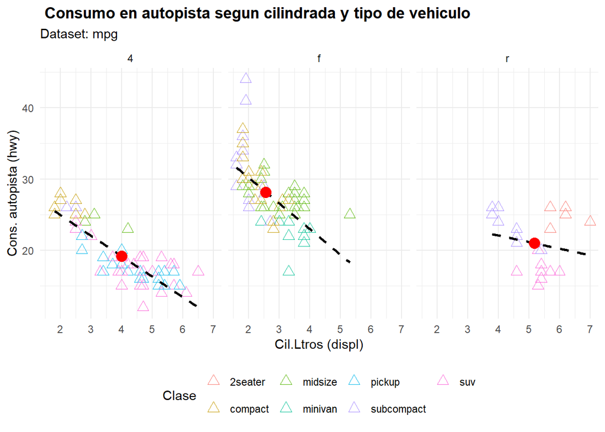

```r
ggplot(mpg, aes(x=displ, y=hwy, color= class))+
         geom_point(shape= 2, size = 3)+
  facet_grid(~ drv)+
  labs(x= "Cil.Ltros (displ)",
       y= "Cons. autopista (hwy)",
       title= " Consumo en autopista segun cilindrada y tipo de vehiculo",
       subtitle="Dataset: mpg ",
       color= "Clase")+
  geom_smooth(method = lm,
              se = FALSE,
              colour="black",
              linetype= 2
)+
  theme_minimal()+
  theme(legend.position = "bottom", plot.title = element_text(face = "bold"))+
  geom_point(
    data = centros,
    aes(x = displ, y = hwy),
    color = "red",
    size = 4
  )
```

**Nota:** En este gráfico trabajo con el dataset mpg para analizar la relación entre la cilindrada del motor y el consumo en autopista, utilizando el color para diferenciar la clase de vehículo y separando el análisis por tipo de tracción mediante facetas, lo que me permite comparar los comportamientos sin mezclar los grupos; primero calculo los valores medios de cilindrada y consumo para cada tipo de tracción con el objetivo de obtener un punto representativo de cada grupo, luego represento todas las observaciones individuales con puntos para ver la dispersión real de los datos, añado una línea de regresión lineal discontinua que resume la tendencia general entre ambas variables y, finalmente, incorporo puntos rojos que indican el vehículo promedio de cada tipo de tracción, todo ello con un diseño limpio y una leyenda clara que facilita la interpretación visual y la comparación entre grupos.

**1.2 Mapa Europa**

**Haz un mapa de Europa coloreando cada país según su población estimada (pop_est), usando los datos obtenidos con ne_countries(). Los países más poblados deben aparecer en colores más intensos. Añade título, leyenda y un estilo limpio.**

```r
library(rnaturalearth)
library(rnaturalearthdata)
library(sf)
library(leaflet)
world_act <- ne_countries(scale = "medium", returnclass = "sf")
# Descargamos el mapa mundial de países desde Natural Earth
# Usamos una escala media para equilibrar detalle y peso del objeto
# El argumento returnclass = "sf" permite trabajar el mapa directamente con ggplot
# Referencia: https://bookdown.org/keilor_rojas/CienciaDatos/elaboraci%C3%B3n-de-mapas-en-r.html
world_act
```

|  | featurecla | scalerank | labelrank | sovereignt | sov_a3 | adm0_dif | level | type | tlc | admin | adm0_a3 | geou_dif | geounit | gu_a3 | su_dif | subunit | su_a3 | brk_diff | name | name_long | brk_a3 | brk_name | brk_group | abbrev | postal | formal_en | formal_fr | name_ciawf | note_adm0 | … |
| --- | --- | --- | --- | --- | --- | --- | --- | --- | --- | --- | --- | --- | --- | --- | --- | --- | --- | --- | --- | --- | --- | --- | --- | --- | --- | --- | --- | --- | --- | --- |
| 1 | Admin-0 country | 1 | 3 | Zimbabwe | ZWE | 0 | 2 | Sovereign country | 1 | Zimbabwe | ZWE | 0 | Zimbabwe | ZWE | 0 | Zimbabwe | ZWE | 0 | Zimbabwe | Zimbabwe | ZWE | Zimbabwe | NA | Zimb. | ZW | Republic of Zimbabwe | NA | Zimbabwe | NA | … |
| 2 | Admin-0 country | 1 | 3 | Zambia | ZMB | 0 | 2 | Sovereign country | 1 | Zambia | ZMB | 0 | Zambia | ZMB | 0 | Zambia | ZMB | 0 | Zambia | Zambia | ZMB | Zambia | NA | Zambia | ZM | Republic of Zambia | NA | Zambia | NA | … |
| 3 | Admin-0 country | 1 | 3 | Yemen | YEM | 0 | 2 | Sovereign country | 1 | Yemen | YEM | 0 | Yemen | YEM | 0 | Yemen | YEM | 0 | Yemen | Yemen | YEM | Yemen | NA | Yem. | YE | Republic of Yemen | NA | Yemen | NA | … |
| 4 | Admin-0 country | 3 | 2 | Vietnam | VNM | 0 | 2 | Sovereign country | 1 | Vietnam | VNM | 0 | Vietnam | VNM | 0 | Vietnam | VNM | 0 | Vietnam | Vietnam | VNM | Vietnam | NA | Viet. | VN | Socialist Republic of Vietnam | NA | Vietnam | NA | … |
| 5 | Admin-0 country | 5 | 3 | Venezuela | VEN | 0 | 2 | Sovereign country | 1 | Venezuela | VEN | 0 | Venezuela | VEN | 0 | Venezuela | VEN | 0 | Venezuela | Venezuela | VEN | Venezuela | NA | Ven. | VE | Bolivarian Republic of Venezuela | República Bolivariana de Venezuela | Venezuela | NA | … |
| 6 | Admin-0 country | 6 | 6 | Vatican | VAT | 0 | 2 | Sovereign country | 1 | Vatican | VAT | 0 | Vatican | VAT | 0 | Vatican | VAT | 0 | Vatican | Vatican | VAT | Vatican | NA | Vat. | V | State of the Vatican City | NA | Holy See (Vatican City) | NA | … |
| 7 | Admin-0 country | 1 | 4 | Vanuatu | VUT | 0 | 2 | Sovereign country | 1 | Vanuatu | VUT | 0 | Vanuatu | VUT | 0 | Vanuatu | VUT | 0 | Vanuatu | Vanuatu | VUT | Vanuatu | NA | Van. | VU | Republic of Vanuatu | NA | Vanuatu | NA | … |
| 8 | Admin-0 country | 1 | 3 | Uzbekistan | UZB | 0 | 2 | Sovereign country | 1 | Uzbekistan | UZB | 0 | Uzbekistan | UZB | 0 | Uzbekistan | UZB | 0 | Uzbekistan | Uzbekistan | UZB | Uzbekistan | NA | Uzb. | UZ | Republic of Uzbekistan | NA | Uzbekistan | NA | … |
| 9 | Admin-0 country | 1 | 4 | Uruguay | URY | 0 | 2 | Sovereign country | 1 | Uruguay | URY | 0 | Uruguay | URY | 0 | Uruguay | URY | 0 | Uruguay | Uruguay | URY | Uruguay | NA | Ury. | UY | Oriental Republic of Uruguay | NA | Uruguay | NA | … |
| 10 | Admin-0 country | 3 | 6 | Federated States of Micronesia | FSM | 0 | 2 | Sovereign country | 1 | Federated States of Micronesia | FSM | 0 | Federated States of Micronesia | FSM | 0 | Federated States of Micronesia | FSM | 0 | Micronesia | Federated States of Micronesia | FSM | Micronesia | NA | F.S.M. | FSM | Federated States of Micronesia | NA | Micronesia, Federated States of | NA | … |

[output cut: 232 more lines]

```r
world_act1 <- world_act %>%
  select(continent, pop_est, geounit=name_long, geometry) %>%
  mutate(pop_est=log10(pop_est)) %>%
  filter(continent== "Europe")
# Hago una limpieza rápida y extraigo únicamente las variables con las que voy a trabajar.

world_act1
```

|  | continent | pop_est | geounit | geometry |
| --- | --- | --- | --- | --- |
| 1 | Europe | 2.916454 | Vatican |  |
| 2 | Europe | 5.032619 | Jersey |  |
| 3 | Europe | 4.797904 | Guernsey |  |
| 4 | Europe | 4.927288 | Isle of Man |  |
| 5 | Europe | 7.825000 | United Kingdom |  |
| 6 | Europe | 7.647238 | Ukraine |  |
| 7 | Europe | 6.933226 | Switzerland |  |
| 8 | Europe | 7.012223 | Sweden |  |
| 9 | Europe | 7.672807 | Spain |  |
| 10 | Europe | 6.736721 | Slovakia |  |

[output cut: 40 more lines]

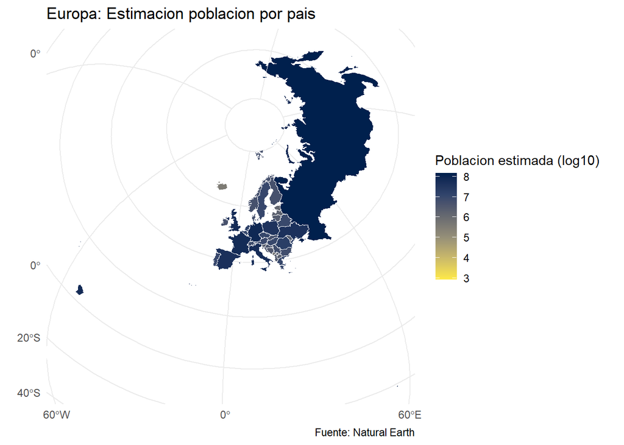

```r
g_mapa <- ggplot(data = world_act1) +
  geom_sf(aes(fill=pop_est), color= "white", linewidth= 0.25)+
  scale_fill_viridis_c(option = "cividis" ,  direction = -1 )+
  labs(
    title= "Europa: Estimacion poblacion por pais",
    fill= "Poblacion estimada (log10)",
    caption= "Fuente: Natural Earth"
  )+
  theme_minimal()+
  coord_sf(crs = 3035)

g_mapa
```

```r
# Aquí preparo un objeto espacial (ggplot) con los países europeos y construyo un mapa coroplético (mejor visión al momento de ver el mapa) donde el color representa la población estimada en escala logarítmica, permitiendo una comparación visual clara entre países con tamaños poblacionales muy distintos.
```

**Nota:** En este ejercicio descargo el mapa mundial de países desde Natural Earth utilizando una escala media y el formato sf, lo que me permite trabajar directamente con ggplot, luego realizo una limpieza básica de los datos seleccionando únicamente el continente, la población estimada y la geometría, aplico una transformación logarítmica a la población para reducir la asimetría entre países muy poblados y menos poblados y filtro únicamente los países europeos, y finalmente construyo un mapa coroplético en el que el color representa la población estimada, usando una paleta continua invertida para que los países más poblados aparezcan con tonos más intensos, incorporando un diseño limpio y una proyección adecuada para Europa que facilita la comparación visual entre países.

## 2 Sección : Funciones

**2.1. Genere una función llamada clasificar_flores() que reciba el dataset iris (instalado en R) por defecto y cree una nueva variable llamada tamaño_petalo, de forma que si la variable Petal.Length es mayor a 4 devuelva “Largo” y en caso contrario devuelva “Corto”.**

```r
head(iris)
```

|  | Sepal.Length | Sepal.Width | Petal.Length | Petal.Width | Species |
| --- | --- | --- | --- | --- | --- |
| 1 | 5.1 | 3.5 | 1.4 | 0.2 | setosa |
| 2 | 4.9 | 3.0 | 1.4 | 0.2 | setosa |
| 3 | 4.7 | 3.2 | 1.3 | 0.2 | setosa |
| 4 | 4.6 | 3.1 | 1.5 | 0.2 | setosa |
| 5 | 5.0 | 3.6 | 1.4 | 0.2 | setosa |
| 6 | 5.4 | 3.9 | 1.7 | 0.4 | setosa |

```r
names(iris)
```

```
## [1] "Sepal.Length" "Sepal.Width"  "Petal.Length" "Petal.Width"  "Species"
```

```r
min(iris$Petal.Length)
```

```
## [1] 1
```

```r
max(iris$Petal.Length)
```

```
## [1] 6.9
```

```r
clasificar_flores <- function(data = iris) {

  data$tamano_petalo <- NA

  for (i in 1:nrow(data)) {

    if (data$Petal.Length[i] > 4) {
      data$tamano_petalo[i] <- "Largo"
    } else {
      data$tamano_petalo[i] <- "Corto"
    }

  }

  return(data)
}

iris_clasificado <- clasificar_flores()

head(iris_clasificado[, c("Petal.Length", "tamano_petalo")])
```

|  | Petal.Length | tamano_petalo |
| --- | --- | --- |
| 1 | 1.4 | Corto |
| 2 | 1.4 | Corto |
| 3 | 1.3 | Corto |
| 4 | 1.5 | Corto |
| 5 | 1.4 | Corto |
| 6 | 1.7 | Corto |

```r
table(iris_clasificado$tamano_petalo)
```

```
##
## Corto Largo
##    66    84
```

**Nota:** En este ejercicio comienzo explorando el dataset iris para verificar su estructura, los nombres de las variables y el rango de valores de Petal.Length, lo que me permite comprobar que el umbral elegido es coherente, y a partir de ahí defino una función llamada clasificar_flores() que recibe el dataset por defecto, crea una nueva variable vacía llamada tamano_petalo y recorre el conjunto de datos fila por fila mediante un bucle for, utilizando una estructura if/else para clasificar cada observación como “Largo” cuando la longitud del pétalo es mayor que 4 o “Corto” en caso contrario, devolviendo finalmente el dataset con la nueva columna añadida; por último, ejecuto la función, inspecciono las primeras filas para validar la clasificación y utilizo una tabla de frecuencias para comprobar cuántas observaciones quedan en cada categoría.

**2.2 En este ejercicio vamos a programar una pequeña simulación divertida**

```r
adivina_numero <- function() {

  numero_secreto <- sample(1:50, 1)
  intentos_max <- 10

  min <- 1
  max <- 50

  for (i in 1:intentos_max) {

    intento <- sample(min:max, 1)

    if (intento == numero_secreto) {
      return(
        paste("Enhorabuena, has encontrado el numero",
              numero_secreto, "en", i, "intentos")
      )

    } else if (intento < numero_secreto) {
      cat("Intento", i, ":", intento, "- Bajo\n")
      min <- intento + 1

    } else {
      cat("Intento", i, ":", intento, "- Alto\n")
      max <- intento - 1
    }
  }

  return(
    paste("No se encontro el numero.",
          "El numero secreto era", numero_secreto)
  )
}

adivina_numero()
```

```
## Intento 1 : 8 - Alto
## Intento 2 : 4 - Bajo
## Intento 3 : 7 - Alto
```

```
## [1] "Enhorabuena, has encontrado el numero 6 en 4 intentos"
```

## 3 Sección : Distribucion de Probabilidades

**3.1. Simule 10 mil valores de una distribución 𝑁(50,10^2). Calcule la probabilidad de que la variable tome valores superiores a 60.**

```r
x_act <- rnorm(n = 10000, mean = 50, sd =10 )

probabilidad_ejercicio <- mean(x_act > 60)

probabilidad_ejercicio
```

```
## [1] 0.158
```

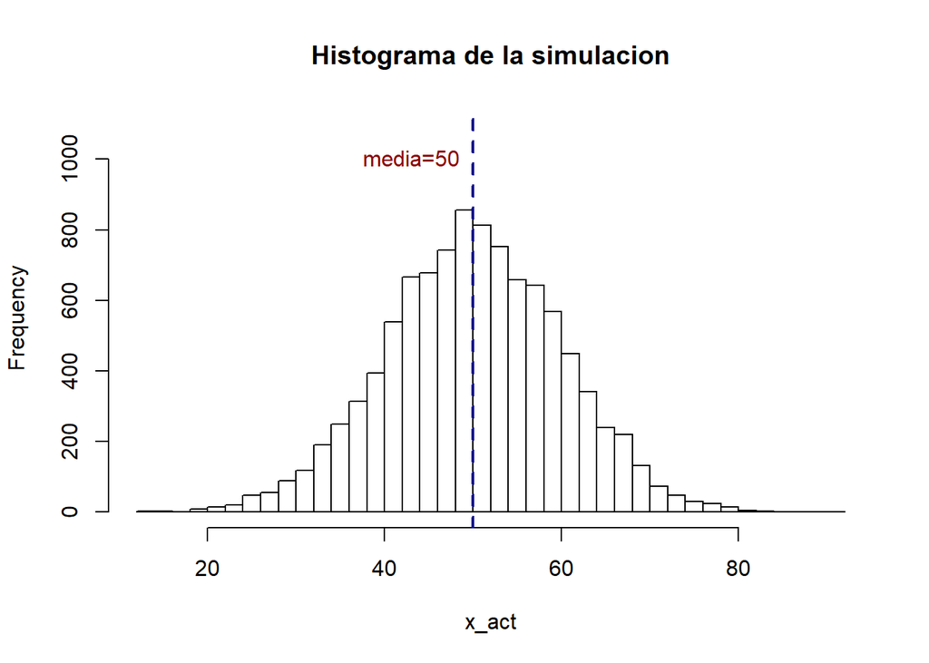

```r
hist(x_act,
     breaks = 30, col = "white", main = "Histograma de la simulacion", ylim= c(0,1100))
abline(v=50, col="blue4", lwd= 2, lty=2)

text(x = 50,  y = 1000,  labels = "media=50",  col = "red4",  pos = 2)
```

**Nota:** En este ejercicio simulo 10 000 observaciones de una distribución normal con media 50 y desviación estándar 10 utilizando la función rnorm(), lo que me permite aproximar el comportamiento teórico de la variable mediante simulación, y a partir de esos valores estimo la probabilidad de que la variable tome valores superiores a 60 calculando la proporción de observaciones que cumplen dicha condición, es decir, interpretando la media de una expresión lógica como una frecuencia relativa, obteniendo así una estimación empírica de la probabilidad solicitada.

**3.2. En estadística, el Teorema Central del Límite indica que muchas distribuciones, bajo ciertas condiciones, tienden a aproximarse a una distribución normal. En este ejercicio deberás simular datos de dos distribuciones diferentes: Uniforme y Poisson. Explica en qué casos y por qué estas distribuciones se aproximan a una normal.**

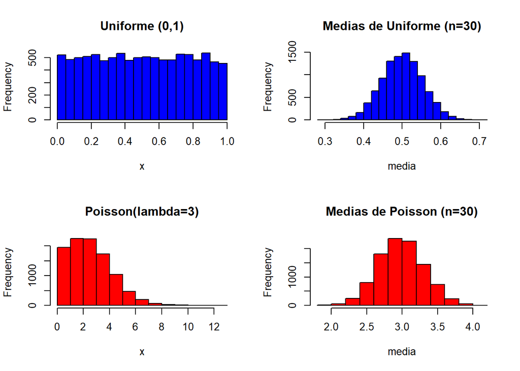

```r
num_rep <- 10000
num_muestra <- 30

m_unif <- runif(num_rep, min = 0, max=1)

medias_unif <- replicate(num_rep, mean(runif(num_muestra,0,1)))

par(mfrow = c(2,2))

hist(m_unif, main= "Uniforme (0,1)", xlab = "x", col= "blue")

hist(medias_unif, main = paste0("Medias de Uniforme (n=", num_muestra, ")"), xlab = "media", col = "blue")


#Poisson

lambda_act <-  3

x_poisson <- rpois(num_rep, lambda = lambda_act)

medias_pois <- replicate(num_rep, mean(rpois(num_muestra, lambda = lambda_act)))

hist(x_poisson, main = paste0("Poisson(lambda=", lambda_act, ")"), xlab = "x", col = "red")
hist(medias_pois, main = paste0("Medias de Poisson (n=", num_muestra, ")"),xlab = "media", col = "red")
```

**Nota:** En este ejercicio aplico el Teorema Central del Límite mediante simulación, comenzando por definir el número de repeticiones y el tamaño muestral, y genero primero datos de una distribución uniforme (0,1) para mostrar que sus valores originales no siguen una forma normal, mientras que al calcular repetidamente las medias muestrales de tamaño 30 se obtiene una distribución mucho más simétrica y con forma de campana; posteriormente repito el mismo procedimiento con una distribución Poisson con parámetro lambda = 3, observando que aunque los datos originales son discretos y asimétricos, la distribución de sus medias muestrales también se aproxima a una normal cuando el tamaño de muestra es suficientemente grande, lo que confirma que, bajo las condiciones de independencia y varianza finita, la media muestral tiende a una distribución normal independientemente de la distribución original.

## 4 Seccion : Web Scrapping

**4.1. Obtén de https://quotes.toscrape.com/ las citas de las primeras 5 páginas. Debes recoger en un dataset la cita y el autor.**

```r
library(rvest) #Web scraping
library(purrr) #captar toda la información / nos permite hacer bucles
```

```r
pages_act <- paste0("https://quotes.toscrape.com/page/", 1:5, "/")

scrape_act <- function(url_actividad){

  page <- read_html(url_actividad)

  bloques <- page %>% html_elements(".quote")

  data.frame(
    Cita = bloques %>%
      html_element(".text") %>%
      html_text(trim = TRUE)%>%
      iconv(from = "UTF-8", to = "ASCII", sub = ""),


    Autor = bloques %>%
      html_element(".author") %>%
      html_text(trim = TRUE)%>%
      iconv(from = "UTF-8", to = "ASCII", sub = ""),

    stringsAsFactors = FALSE
  )
}

quotes_df <- map_df(pages_act, scrape_act)

quotes_df
```

| Cita | Autor |
| --- | --- |
| The world as we have created it is a process of our thinking. It cannot be changed without changing our thinking. | Albert Einstein |
| It is our choices, Harry, that show what we truly are, far more than our abilities. | J.K. Rowling |
| There are only two ways to live your life. One is as though nothing is a miracle. The other is as though everything is a miracle. | Albert Einstein |
| The person, be it gentleman or lady, who has not pleasure in a good novel, must be intolerably stupid. | Jane Austen |
| Imperfection is beauty, madness is genius and it's better to be absolutely ridiculous than absolutely boring. | Marilyn Monroe |
| Try not to become a man of success. Rather become a man of value. | Albert Einstein |
| It is better to be hated for what you are than to be loved for what you are not. | Andr Gide |
| I have not failed. I've just found 10,000 ways that won't work. | Thomas A. Edison |
| A woman is like a tea bag; you never know how strong it is until it's in hot water. | Eleanor Roosevelt |
| A day without sunshine is like, you know, night. | Steve Martin |

[output cut: 40 more lines]

**Nota:** En este ejercicio realizo un web scraping del sitio quotes.toscrape.com para extraer las citas y sus autores de las primeras cinco páginas, comenzando por construir un vector con las URLs a partir de un patrón común y utilizando la librería rvest para leer y parsear el contenido HTML de cada página, luego defino una función que identifica los bloques de citas mediante selectores CSS, extrae el texto de la cita y el nombre del autor desde los elementos correspondientes y limpia los caracteres especiales forzando la conversión a ASCII para evitar problemas de codificación, y finalmente aplico esta función a todas las páginas usando map_df del paquete purrr, lo que me permite recorrer automáticamente las URLs y combinar los resultados en un único dataset estructurado listo para su análisis.